# Stat 382 Final Project

# Data Cleaning

#### Variable Meaning

AI = Native American, percentage of registered voters AP = Asian and Pacific Islander, percentage of registered voters BH = Black, percentage of registered voters HP = Hisanpic, percentage of registered voters WH = White, percentage of registered voters OT = Other, percentage of registered voters UK = race unknown, percentage of registered voters Total_votes = Total votes casted TOTAL VOTERS = Total number of registered voters voteChange = Change in total number of votes casted, compared with 2016 Education = Percentage of people aged 25 and older who has a bachelor's degree pop_density = people per square mile new_margin = Democrat's margin of victory in 2020 in percent old_margin = Democrat's margin of victory in 2016 in percent margin_change = margin change between 2016 and 2020 current_result = Which party won in 2020 past_result = which party won in 2016 senior = percentage of registered voter who are over 65 years old youth = percentage of registered voter who are under 30 years old in_atlanta_metro = Is the county part of the Atlanta metropolitan area or not

### Loading Election and Electorate Data

```r
library(readxl)
GAelection = as.data.frame(read_excel("C:/Users/alber/Downloads/Stat382/Project4/Georgia.xlsx"))[-160,]
GAvoter =  as.data.frame(read_excel("C:/Users/alber/Downloads/Stat382/Project4/Active_Voters_by_Race_Gender_as_of_November_1_2020.xlsx"))[-160,c(-1:-23)]
GAvoter[,-1] = sapply(GAvoter[,-1], function(x) return(round(x*100/GAvoter$`TOTAL VOTERS`,2)))
ga2016 = as.data.frame(read_excel("C:/Users/alber/Downloads/Stat382/Project4/GA2016.xlsx"))
GA = cbind(GAelection, GAvoter)
BidenVoteShare = round(100*GA$`B_Total Votes`/GA$Total, 2)
TrumpVoteShare = round(100*GA$`T_Total Votes`/GA$Total, 2)
GA$BidenVoteShare = BidenVoteShare
GA$TrumpVoteShare = TrumpVoteShare
data = GA[,c(1,17:27)]
data$Turnout = round(100*data$Total/data$`TOTAL VOTERS`,2)
data$voteChange = round((100*data$Total/ga2016$Total)-100,2)
turnout2016 = as.data.frame(read_excel("C:/Users/alber/Downloads/Stat382/Project4/gaTurnout2016.xlsx"))
data$TurnoutChange = data$Turnout-turnout2016$Turnout
names(data)[names(data) == "Total"] = "Total_votes"
```

### Add in population density and income

```r
pop = read.csv("C:/Users/alber/Downloads/Stat382/Project4/LandArea.csv")[,c(2:4)]
pop$Population = as.numeric(pop$Population)
pop$pop_density=pop$Population/pop$Land.Area
data=merge(data,pop)
data=subset(merge(pop,data), select=-c(Population,Land.Area))
income = as.data.frame(read_excel("C:/Users/alber/Downloads/Stat382/Project4/incomeED.xlsx"))[,c(-2,-4,-5,-6)]
data=merge(data,income)
```

### Add in percentage of seniors and youth

```r
age = as.data.frame(read_excel("C:/Users/alber/Downloads/Stat382/Project4/Active_Voters_by_Race_Gender_and_Age_as_of_November_1_2020.xlsx"))[c(seq(1,1753,by=11)),c(-1:-25)][-160,]
data = cbind(data,age[,c(-1)])
```

### Create Categorical Variables

#### Won by Clinton/Trump in 2016

#### Atlanta Metro Area

```r
data$old_margin = 100*(ga2016$HRCshare-ga2016$DJTShare)
data$new_margin = (data$BidenVoteShare-data$TrumpVoteShare)
data$margin_change = data$new_margin-data$old_margin
data$past_result[data$old_margin>0] = "Dem"
data$past_result[data$old_margin<0] = "Rep"
data$past_result = as.factor(data$past_result)
data$current_result[data$new_margin>0] = "Dem"
data$current_result[data$new_margin<0] = "Rep"
data$current_result = as.factor(data$current_result)
urbanicity = as.data.frame(read_excel("C:/Users/alber/Downloads/Stat382/Project4/Sub Urb Rural.xlsx"))
data$urbanicity = urbanicity$`Sub/Urb/Rural`
atlanta = c("Fulton", "DeKalb", "Gwinnett", "Cobb", "Clayton", "Cherokee", "Douglas", "Fayette", "Henry", "Rockdale", "Bartow", "Coweta", "Hall", "Forsyth", "Paulding")
data$in_atlanta_metro[data$County %in% atlanta==TRUE] = "Yes"
data$in_atlanta_metro[data$County %in% atlanta==FALSE] = "No"
```

Save Cleaned Data

```r
library(writexl)
write_xlsx(data,"C:/Users/alber/Downloads/Stat382/Project4/organized_data.xlsx")
```

# Load cleaned data

```r
input = as.data.frame(read_excel("C:/Users/alber/Downloads/Stat382/Project4/Cleaned_Data.xlsx"))
input[,c(24:27)] = lapply(input[,c(24:27)],as.factor)
```

Hypotheses: 1. More educated counties -> more Democratic 2. More educated counties -> shifted more Democratic in the past 4 years 3. Turnout increased more in White counties 4. Higher population density -> more Democratic 5. Higher income counties -> shifted more Democratic in the past 4 years 6. Turnout increase higher in minority counties (<60% White) 7. Older counties are more Republican #Ask Professor whether to weight the ratios ORGANIZATION Variables: *Education (quantitative) linear association Income (quantitative) significance test Urban/Suburban/Rural (categorical) ANOVA Racial breakdown linear association barplot Turnout (urban/suburban/rural ANOVA) histogram Change from 2016 Population Density 2016 result by party (categorical) Share of 65+ or <30

# Exploratory Analysis

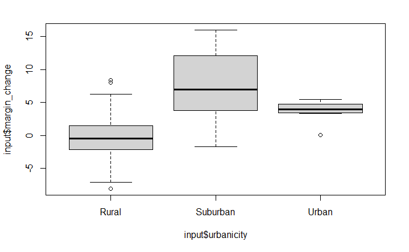

```r
boxplot(input$margin_change~input$urbanicity)
```

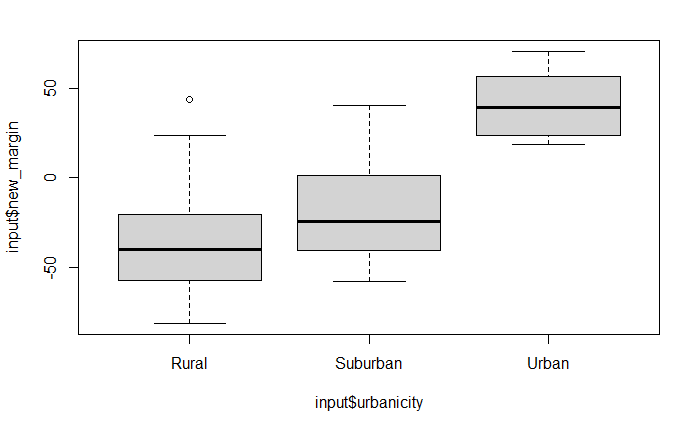

```r
boxplot(input$new_margin~input$urbanicity)
```

```r
test <- aov(BidenVoteShare~urbanicity, data = input)
summary(test)
```

```
             Df Sum Sq Mean Sq F value  Pr(>F)
urbanicity    2  12172    6086    34.3 4.5e-13 ***
Residuals   156  27678     177
---
Signif. codes:  0 ‘***’ 0.001 ‘**’ 0.01 ‘*’ 0.05 ‘.’ 0.1 ‘ ’ 1
```

```r
TukeyHSD(test)
```

```
  Tukey multiple comparisons of means
    95% family-wise confidence level

Fit: aov(formula = BidenVoteShare ~ urbanicity, data = input)

$urbanicity
                    diff       lwr      upr     p adj
Suburban-Rural  8.767771  2.339225 15.19632 0.0043224
Urban-Rural    38.604938 27.098661 50.11121 0.0000000
Urban-Suburban 29.837167 17.295253 42.37908 0.0000002
```